# ch03 - gghistostats

2020-05-04T11:10:39+09:00

## Intro

> A picture is worth a thousand words — English Language Adage The simple graph has brought more information to the data analyst’s mind than any other device. — John Tukey

한장의 그림이 수천단어보다 가치가 있다는 영어속담과, 명료한 시각화가 데이터분석가에게 다른 어떤 도구보다 더 많은 정보를 제공한다는 유명한 데이터 과학자의 조언. 핵심은 시각화이다.

본 장에서는 `ggplot2` 패키지를 활용한 시각화를 먼저 보여줄 것이다. 먼저 간단하게 `ggplot2` 패키지에 소개하자면 `Grammar of Graphics`[^1]의 철학을 담아서 `R` 생태계에서 유명한 학자 중, `Hadley Wickham`에 의해 주도적으로 개발되었다. 그래프에도 문법이 있다는 패키지의 철학 아래, `R`의 시각화는 괄목할만한 발전을 이루었고 이는 `R`의 대중화에도 큰 영향을 끼쳤다.

이제 본격적으로 `R` 시각화를 작성해보자.

## I. 사전준비

본 장에서는 시각화를 위해서 `ggplot2`를 주요 패키지로 사용한다. `ggplot2` 패키지를 설치했다고 가정한다. 만약 처음 패키지를 설치하는 사람이라면 [R 패키지 설치](https://wikidocs.net/58057)[^2]에서 다시 한번 R 패키지 주요 생태계에 대해 이해하도록 한다.

Studio를 열고 아래 코드를 실행하자:

```r
library(ggplot2)
library(ggstatsplot)
```

이번에는 보고서에 작성할 시각화 보고서를 작성해보자.

## II. 데이터셋 - 텍사스 부동산 판매데이터

대한민국에서 가장 중요한 문제중의 하나인 부동산과 관련하여 시각화를 진행하려 한다. 지금은 `ggplot2` 패키지 내에 존재하는 텍사스 부동산 판매데이터를 통해 시각화를 진행하지만, 향후에는 국내 부동산 데이터를 직접 가져와서 시각화를 진행하기를 바란다.

`txhousing` 데이터는 총 `8602`개의 관측치와 `9`개의 변수로 구성이 되어 있다. `txhousing` 데이터의 출처 및 각 변수(`Column`)에 대해 조금 더 자세히 알고 싶다면 `R` 소스코드 에디터에서 help(`txhousing`)을 실행하여 도움말을 참고하기를 바란다.

## III. ggplot2 with Histogram

지난 포스트 [ch02 - Histogram](https://chloevan.github.io/r/datavisualisation/ch02_histogram/)에서 히스토그램에 관한 그래프를 그려봤다.

- 예시) 이 때, 1월과 7월을 비교하는 그래프를 그려본다.

```r
library(dplyr)
```

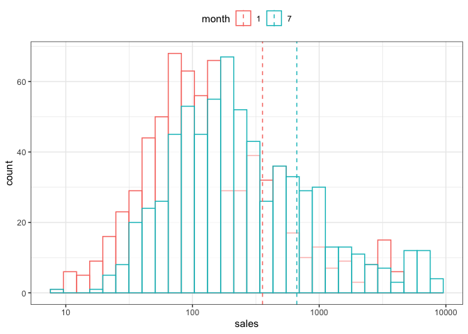

```r
library(ggplot2)
txhousing %>%
  group_by(month) %>%
  summarise(grp.mean = mean(sales, na.rm = TRUE)) -> mean_sales

jan_jul <- txhousing %>%
  filter(month %in% c(1, 7)) %>%
  mutate(month = as.character(month))
mean_jan_jul <- mean_sales %>%
  filter(month %in% c(1,7)) %>%
  mutate(month = as.character(month))

ggplot(jan_jul, aes(x=sales, color=month)) +
  geom_histogram(fill='white', alpha=.5, position = "identity") +
  geom_vline(data = mean_jan_jul,
             aes(xintercept=grp.mean, color=month),
             linetype='dashed') +
  scale_x_log10() +
  theme_bw() +
  theme(legend.position="top")
```

그렇지만, 통계 결과 보고서로 제출하기에는 무언가 아쉽다. ggplot2 패키지 extension 중에서 `ggstatsplot` 패키지가 있다. 꾸준하게 버전이 업데이트 중인 것으로 봐서 통계 보고서 작성 시, 참조하면 좋을 것 같다.

## IV. gghistostats

우선 [tutorial](https://indrajeetpatil.github.io/ggstatsplot/articles/web_only/gghistostats.html)를 참조해서 시각화를 작성해보자.

### (1) Sample Tutorial

```r
library(psych)
dplyr::glimpse(x = psych::sat.act)
```

```
## Rows: 700
## Columns: 6
## $ gender    <int> 2, 2, 2, 1, 1, 1, 2, 1, 2, 2, 1, 2, 1, 2, 2, 2, 2, 2, 1, 2,…
## $ education <int> 3, 3, 3, 4, 2, 5, 5, 3, 4, 5, 3, 4, 4, 4, 3, 4, 3, 4, 4, 4,…
## $ age       <int> 19, 23, 20, 27, 33, 26, 30, 19, 23, 40, 23, 34, 32, 41, 20,…
## $ ACT       <int> 24, 35, 21, 26, 31, 28, 36, 22, 22, 35, 32, 29, 21, 35, 27,…
## $ SATV      <int> 500, 600, 480, 550, 600, 640, 610, 520, 400, 730, 760, 710,…
## $ SATQ      <int> 500, 500, 470, 520, 550, 640, 500, 560, 600, 800, 710, 600,…
```

이 때, `ACT` 변수를 가지고 히스토그램으로 시각화 예제가 나온다. 그대로 복사하기 보다는 하나씩 scripting 해서 각각의 인수(Argument)가 무엇을 의미하는지 음미하면서 실습을 진행한다.

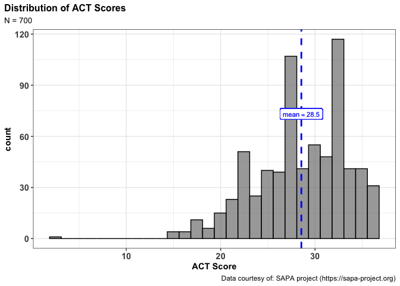

```r
ggstatsplot::gghistostats(
  data = psych::sat.act, # data from which variable is to be taken
  x = ACT, # numeric variable
  results.subtitle = FALSE, # don't run statistical tests
  messages = FALSE, # turn off messages
  xlab = "ACT Score", # x-axis label
  title = "Distribution of ACT Scores", # title for the plot
  subtitle = "N = 700", # subtitle for the plot
  caption = "Data courtesy of: SAPA project (https://sapa-project.org)", # caption for the plot
  centrality.k = 1 # show 1 decimal places for centrality label
)
```

위와 같은 보고서를 출력할 수가 있다.

### (2) 1월과 7월 데이터 비교 그래프

그렇다면 한번 적용해보자. 그런데, 우리는 1월과 7월 데이터만 필요하다. 이 때에는 `grouping.var` 인수와 `plotgrid.args`를 추가하기만 하면 된다.

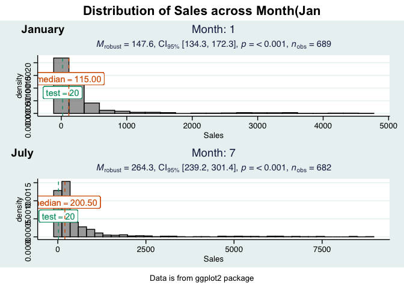

```r
ggstatsplot::grouped_gghistostats(
  data = jan_jul, # jan_jul 변경
  x = sales, # sales
  xlab = "Sales",
  grouping.var = month, # grouping variable 1 = Jan, 7 = Jul
  title.prefix = "Month", # prefix for the fixed title
  k = 1, # number of decimal places in results
  type = "r", # robust test: one-sample percentile bootstrap
  test.value = 20, # test value against which sample mean is to be compared
  test.value.line = TRUE, # show a vertical line at `test.value`
  bar.measure = "density", # density
  centrality.parameter = "median", # plotting centrality parameter
  centrality.line.args = list(color = "#D55E00"),
  centrality.label.args = list(color = "#D55E00"),
  test.value.line.args = list(color = "#009E73"),
  test.value.label.args = list(color = "#009E73"),
  messages = FALSE, # turn off messages
  ggtheme = ggthemes::theme_stata(), # changing default theme
  ggstatsplot.layer = FALSE, # turn off ggstatsplot theme layer
  # arguments relevant for ggstatsplot::combine_plots
  title.text = "Distribution of Sales across Month(Jan",
  caption.text = "Data is from ggplot2 package",
  plotgrid.args = list(
    nrow = 2,
    ncol = 1,
    labels = c("January", "July")
  )
)
```

위 그래프처럼, 그룹별로도 시각화를 작성할 수 있다. 그러나, 조금 더 디자인을 하기 원한다면, `purrr` 패키지와 같이 코드를 작성하는 것을 권하고 있다. - [using ggstatsplot with the purrr package](https://indrajeetpatil.github.io/ggstatsplot/articles/web_only/purrr_examples.html?q=purr)

# V. 향후 방향

- 올해 논문도 써야 하는데, 위 패키지를 근거로 하나둘씩 한글화를 만들어 봐야겠다는 생각이 든다.
- 중간중간 시간이 날 때마다 `논문을 위한 시각화` 함수를 만들어 봐야겠다.
[^1]: Hadley Wickham이 작성한 ggplot2 패키지에 관한 논문을 읽어보는 것을 제안한다. “The Layered Grammar of Graphics”, http://vita.had.co.nz/papers/layered-grammar.pdf